# IODS course project

Marina Peris Llopis

# Introduction to Open Data Science - Course Project

# About the project

```r
# This is a so-called "R chunk" where you can write R code.

date()
```

```
## [1] "Thu Dec 03 20:27:56 2020"
```

My name is Marina and I am doing a PhD about **forest fires**. From this course, I expect to improve my skills with R. I registered in Github a few years ago but I have not used it since then. So I want to become familiar with it and be able to use it for future collaborations. This project is related to the course and contains the exercises that we will do during the next weeks, My respository: [link](https://github.com/mapello3/IODS-project)

# Regression and model validation

Exercise 2 consisted in two parts. First, the **data wrangling** part in which I prepared the data and created the necessary variables to be used for the second part of the exercise. Second, the **analysis** part, in which I used that data to perform a regression analysis.

Linear regression assumes that there is a linear relationship between the dependent variables or predictors and the dependent variable or response. I built several Linear regression models, with the objective of explaining the points or marks of students according to different variables related to learning approaches. Therefore, my dependent variable or response was “Points”, and as independent variables I tried “attitude” “stra”, “surf”, “gender”, “age” and “deep”.

The **multiple regression** models, in which I considered more than one explanatory variable (i.e. *my_model1*, *my_model2*, *my_model3* in the script) were no better than the **simple regression model** with only one explanatory variable. Except “attitude”, all the other variables included in the multiple regression models were non-significant. This means that those variables did not really help to explain “Points”. For this reason, I chose as my final model the one using only “attitude”, so *my_model4* in the script.

According to that model, “attitude” is positively related to “Points”, in such a way that when the attitude of the students increased, the Points also increased (in a 1 to 3.5 proportion).The **R2** of the model was around 0.19, so the variance in the variable attitude explains about 19% of the variance in the variable points. As I see it, this model follows two of the general principles in modeling, simplicity and parsimony. It is possible to explain a lot of variance with only one variable.

```r
date()
```

```
## [1] "Thu Dec 03 20:27:56 2020"
```

Here we go again…

# Logistic regression

#Exercise 3

In exercise 3, I started importing into Rstudio a dataset about students achievement in secondary education of two Portuguese schools. The first part of the exercise consisted on data wrangling, with the objective of preparing the data for further analysis (see script *create_alc* in my data folder in my Github repository). The data wrangling included tasks like joining two datasets and combining duplicated answers.

The final dataset, contains 35 variables and 382 observations. The variables are: “school”,“sex”, “age”,“address”, “famsize”, “Pstatus”, “Medu”, “Fedu”, “Mjob”, “Fjob”, “reason”,“nursery”,“internet”,“guardian” “traveltime”, “studytime”, “failures”, “schoolsup”, “famsup”,“paid”, “activities”, “higher”, “romantic”, “famrel”,“freetime”, “goout”,“Dalc”, “Walc”,“health”,“absences”,“G1”, “G2”,“G3”,“alc_use”, and “high_use”.

The idea was to propose potential variables that could explain the level of Alcohol Consumption among students. My hypothesis is that the variables *Sex*, *number of school absences* and *parent’s cohabitation status* can influence alcohol consumption. I think that males have higher alcohol consumption than females (positive relationship), that a high number of school absences correlates positively with alcohol consumption, and that the status of parents can influence alcohol consumption (higher in families were parents do not cohabit). I checked graphically if there was any kind of correlation between those variables. For that, I created several plots.

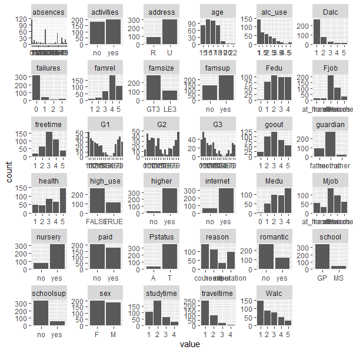

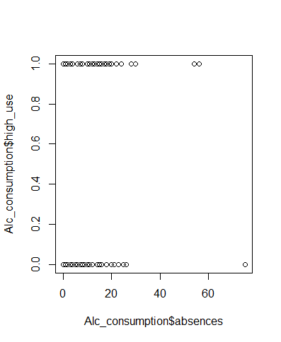

Looking at the previous graph, my hypothesis about the influence of school absences on high/low alcohol use becomes stronger.It is true that there are not as many points in the upper right part of the graph as I expected.

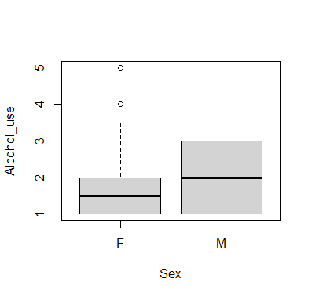

Checking the boxplot, also seems that males have a higher alcohol use than females.

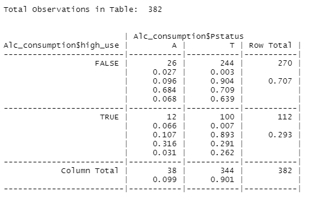

To check the number of cases I performed a Cross tabulation with the variables *high_use* and *Pstatus*. The table shows that the number of students that consume high amounts of alcohol with parents living together (100) is higher than those whose parents live apart (12). In this case, there is an important difference in the number of students with parents cohabiting and with parents living apart, 344 versus 38.

Next step was to develop a **logistic regression model**, which uses as a response a binary variable, which can only take two values. That variable was “high/low alcohol consumption”. I developed two different models. The first one, considering Pstatus, absences and sex to explain high_alc and to prove my hypotheses. And the second one, without Pstatus. The reason was that Pstatus was non-significant in the first model, so I decided to remove it.

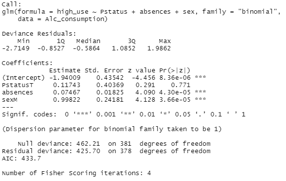

According to Model1, absences and sex influence significantly and in a positive way the use of alcohol. The status of parents does not have a significant effect on use of alcohol. I was correct in two of the potential relationships (both coefficients positive and highly significant, indicating a positive influence), but not with Pstatus.

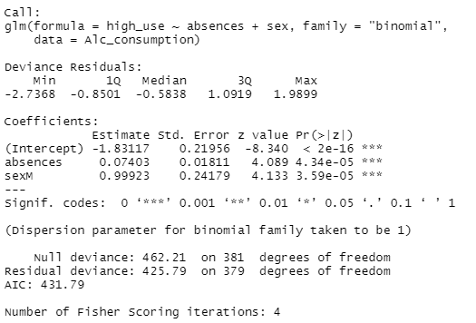

The AIC is lower in Model2, what suggests that we can and it is good to simplify the model as we did (removing one variable).

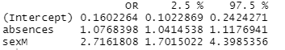

At the end, I decided to use *Model2* as my final model.I calculated the **odds ratios** and the **confidence intervals** for that model. The odds of *males* presenting high alcohol consumption are between 1.7 and 4.3 times the odds of *females*. The odds of students with school absences are lower, but still higher than those attending school (between 1.04 and 1.11).

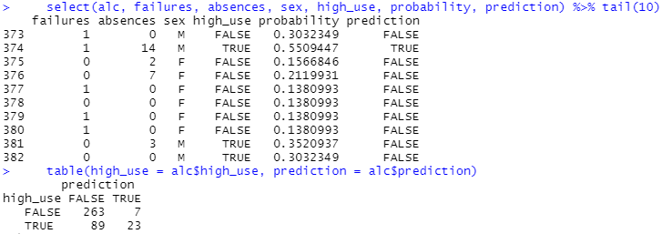

Later on, I calculated the **probabilites** of each student to present high/low alcohol consumption according to the model, as well as a comparison between observations and predictions (second table). According to that table, 89 students that in reality presented high alcohol consumption (TRUE) were predicted to have low alcohol consumption (FALSE) by the model.The predictions versus real values can be seen graphically below.

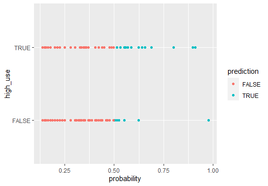

After that, I checked the accuracy of the model by using a **loss function**, which computes the average number of wrong predictions on the training data. The result was 0.251, which means that the proportion of incorrectly classified observations or error is around 25%. If we were guessing, for instance defining a probability of high alcohol consumption of 0 for each student, the error would be 0.293, higher than when using the calculated probabilities from the model.

Finally, I performed a **10-fold cross validation** and I got an error with the testing data of 0.259. A bit higher than the error with the training data. This means that the predictive power of the model is lower when using the testing data.

```r
date()
```

```
## [1] "Thu Dec 03 20:27:56 2020"
```

# Clustering and classification

In exercise 4 we are using a dataset which contains 506 observations of 14 variables, describing housing values of suburbs in Boston. For instance, it contains variables like crime rate by town, NO ppm, pupil-teacher ratio, etc. There are not categorical variables in the original dataset, only numeric and integer.

```r
require(MASS)
data(Boston)
str(Boston)
```

```
## 'data.frame':    506 obs. of  14 variables:
##  $ crim   : num  0.00632 0.02731 0.02729 0.03237 0.06905 ...
##  $ zn     : num  18 0 0 0 0 0 12.5 12.5 12.5 12.5 ...
##  $ indus  : num  2.31 7.07 7.07 2.18 2.18 2.18 7.87 7.87 7.87 7.87 ...
##  $ chas   : int  0 0 0 0 0 0 0 0 0 0 ...
##  $ nox    : num  0.538 0.469 0.469 0.458 0.458 0.458 0.524 0.524 0.524 0.524 ...
##  $ rm     : num  6.58 6.42 7.18 7 7.15 ...
##  $ age    : num  65.2 78.9 61.1 45.8 54.2 58.7 66.6 96.1 100 85.9 ...
##  $ dis    : num  4.09 4.97 4.97 6.06 6.06 ...
##  $ rad    : int  1 2 2 3 3 3 5 5 5 5 ...
##  $ tax    : num  296 242 242 222 222 222 311 311 311 311 ...
##  $ ptratio: num  15.3 17.8 17.8 18.7 18.7 18.7 15.2 15.2 15.2 15.2 ...
##  $ black  : num  397 397 393 395 397 ...
##  $ lstat  : num  4.98 9.14 4.03 2.94 5.33 ...
##  $ medv   : num  24 21.6 34.7 33.4 36.2 28.7 22.9 27.1 16.5 18.9 ...
```

```r
dim(Boston)
```

```
## [1] 506  14
```

I first analyzed the possible relationships between the variables, as well as their **distributions**. None of the variables seem to strictly follow a normal distribution, *rm* (average number of rooms per dwelling) would be the closest one. According to the *Pearson correlation coefficient* shown in the plot, there are highly significant correlations between many variables. For example, indus-tax (+), tax-crim (+), medv-crim (-), etc.

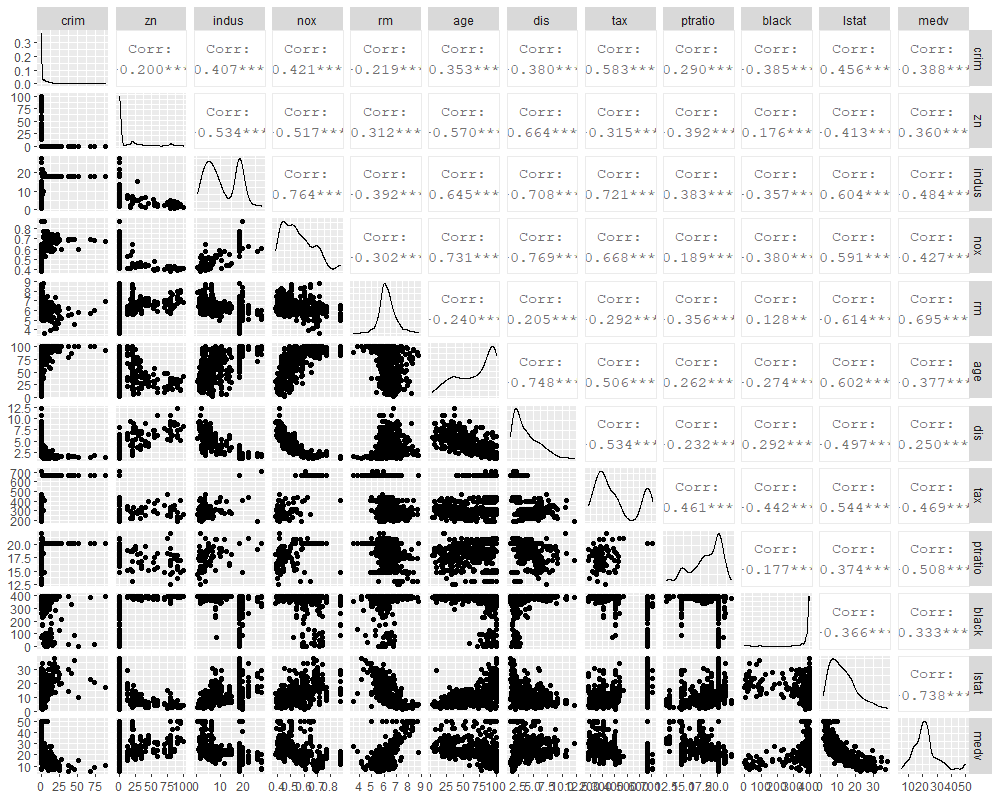

I also created another **correlation plot**, which better shows correlations between variables.

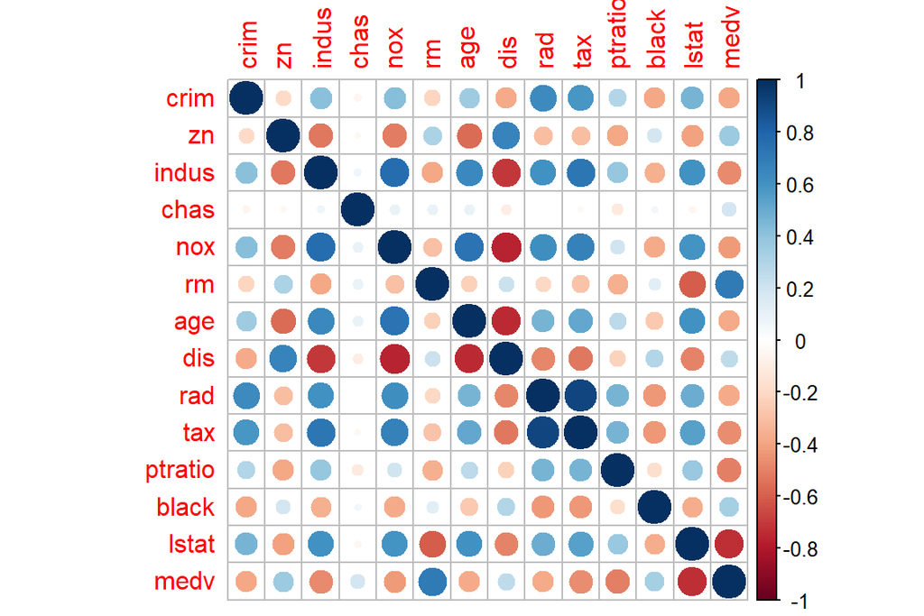

```r
require(corrplot)
require(tidyverse)
cor_matrix<-cor(Boston) %>% round(digits=2)
corrplot(cor_matrix, method="circle")
```

```r
summary(Boston)
```

```
##       crim                zn             indus            chas
##  Min.   : 0.00632   Min.   :  0.00   Min.   : 0.46   Min.   :0.00000
##  1st Qu.: 0.08205   1st Qu.:  0.00   1st Qu.: 5.19   1st Qu.:0.00000
##  Median : 0.25651   Median :  0.00   Median : 9.69   Median :0.00000
##  Mean   : 3.61352   Mean   : 11.36   Mean   :11.14   Mean   :0.06917
##  3rd Qu.: 3.67708   3rd Qu.: 12.50   3rd Qu.:18.10   3rd Qu.:0.00000
##  Max.   :88.97620   Max.   :100.00   Max.   :27.74   Max.   :1.00000
##       nox               rm             age              dis
##  Min.   :0.3850   Min.   :3.561   Min.   :  2.90   Min.   : 1.130
##  1st Qu.:0.4490   1st Qu.:5.886   1st Qu.: 45.02   1st Qu.: 2.100
##  Median :0.5380   Median :6.208   Median : 77.50   Median : 3.207
##  Mean   :0.5547   Mean   :6.285   Mean   : 68.57   Mean   : 3.795
##  3rd Qu.:0.6240   3rd Qu.:6.623   3rd Qu.: 94.08   3rd Qu.: 5.188
##  Max.   :0.8710   Max.   :8.780   Max.   :100.00   Max.   :12.127
##       rad              tax           ptratio          black
##  Min.   : 1.000   Min.   :187.0   Min.   :12.60   Min.   :  0.32
##  1st Qu.: 4.000   1st Qu.:279.0   1st Qu.:17.40   1st Qu.:375.38
##  Median : 5.000   Median :330.0   Median :19.05   Median :391.44
##  Mean   : 9.549   Mean   :408.2   Mean   :18.46   Mean   :356.67
##  3rd Qu.:24.000   3rd Qu.:666.0   3rd Qu.:20.20   3rd Qu.:396.23
##  Max.   :24.000   Max.   :711.0   Max.   :22.00   Max.   :396.90
##      lstat            medv
##  Min.   : 1.73   Min.   : 5.00
##  1st Qu.: 6.95   1st Qu.:17.02
##  Median :11.36   Median :21.20
##  Mean   :12.65   Mean   :22.53
##  3rd Qu.:16.95   3rd Qu.:25.00
##  Max.   :37.97   Max.   :50.00
```

In order to fit a linear discriminant analysis with our data, the considered variables need to be scaled so that they meet the assumption of constant variance.

I **scaled the data** by substracting the mean value to each observation and dividing by the standard deviation. The scaled data is quite different, as there are now negative values (minimum values of the variables) and smaller ranges (i.e. variable *zn*).

```r
boston_scaled <- scale(Boston)
boston_scaled <- as.data.frame(boston_scaled)
summary(boston_scaled)
```

```
##       crim                 zn               indus              chas
##  Min.   :-0.419367   Min.   :-0.48724   Min.   :-1.5563   Min.   :-0.2723
##  1st Qu.:-0.410563   1st Qu.:-0.48724   1st Qu.:-0.8668   1st Qu.:-0.2723
##  Median :-0.390280   Median :-0.48724   Median :-0.2109   Median :-0.2723
##  Mean   : 0.000000   Mean   : 0.00000   Mean   : 0.0000   Mean   : 0.0000
##  3rd Qu.: 0.007389   3rd Qu.: 0.04872   3rd Qu.: 1.0150   3rd Qu.:-0.2723
##  Max.   : 9.924110   Max.   : 3.80047   Max.   : 2.4202   Max.   : 3.6648
##       nox                rm               age               dis
##  Min.   :-1.4644   Min.   :-3.8764   Min.   :-2.3331   Min.   :-1.2658
##  1st Qu.:-0.9121   1st Qu.:-0.5681   1st Qu.:-0.8366   1st Qu.:-0.8049
##  Median :-0.1441   Median :-0.1084   Median : 0.3171   Median :-0.2790
##  Mean   : 0.0000   Mean   : 0.0000   Mean   : 0.0000   Mean   : 0.0000
##  3rd Qu.: 0.5981   3rd Qu.: 0.4823   3rd Qu.: 0.9059   3rd Qu.: 0.6617
##  Max.   : 2.7296   Max.   : 3.5515   Max.   : 1.1164   Max.   : 3.9566
##       rad               tax             ptratio            black
##  Min.   :-0.9819   Min.   :-1.3127   Min.   :-2.7047   Min.   :-3.9033
##  1st Qu.:-0.6373   1st Qu.:-0.7668   1st Qu.:-0.4876   1st Qu.: 0.2049
##  Median :-0.5225   Median :-0.4642   Median : 0.2746   Median : 0.3808
##  Mean   : 0.0000   Mean   : 0.0000   Mean   : 0.0000   Mean   : 0.0000
##  3rd Qu.: 1.6596   3rd Qu.: 1.5294   3rd Qu.: 0.8058   3rd Qu.: 0.4332
##  Max.   : 1.6596   Max.   : 1.7964   Max.   : 1.6372   Max.   : 0.4406
##      lstat              medv
##  Min.   :-1.5296   Min.   :-1.9063
##  1st Qu.:-0.7986   1st Qu.:-0.5989
##  Median :-0.1811   Median :-0.1449
##  Mean   : 0.0000   Mean   : 0.0000
##  3rd Qu.: 0.6024   3rd Qu.: 0.2683
##  Max.   : 3.5453   Max.   : 2.9865
```

**Linear discriminant analysis** is a classification method, with which we model a categorical target variable, *crime*, using all the other variables in the dataset as independent variables.

```r
bins <- quantile(boston_scaled$crim)
crime <- cut(boston_scaled$crim, breaks = bins, include.lowest = TRUE, label=c("low", "med_low", "med_high", "high"))
      boston_scaled <- dplyr::select(boston_scaled, -crim)
      boston_scaled <- data.frame(boston_scaled, crime)

n <- nrow(boston_scaled)
ind <- sample(n,  size = n * 0.8)
train <- boston_scaled[ind,]
lda.fit <- lda(crime~., data = train)
lda.fit
```

```
## Call:
## lda(crime ~ ., data = train)
##
## Prior probabilities of groups:
##       low   med_low  med_high      high
## 0.2574257 0.2376238 0.2673267 0.2376238
##
## Group means:
##                   zn      indus        chas        nox         rm        age
## low       0.96955175 -0.9315721 -0.08304540 -0.8942940  0.4590122 -0.8990969
## med_low  -0.09799618 -0.2328305 -0.02626030 -0.5476074 -0.1917963 -0.3158026
## med_high -0.39036962  0.2090621  0.16512651  0.4242128  0.1261354  0.3844346
## high     -0.48724019  1.0172418 -0.06727176  1.0464766 -0.3490951  0.7895559
##                 dis        rad        tax      ptratio       black       lstat
## low       0.9325653 -0.6892330 -0.7412579 -0.436480578  0.37858844 -0.77792057
## med_low   0.3808696 -0.5488034 -0.4778106  0.002736668  0.31690731 -0.07399120
## med_high -0.3843258 -0.4033841 -0.3010444 -0.403301690  0.07189409 -0.03410224
## high     -0.8315722  1.6368728  1.5131579  0.779315100 -0.74500780  0.85101425
##                 medv
## low       0.54175513
## med_low  -0.07254254
## med_high  0.25265292
## high     -0.70725320
##
## Coefficients of linear discriminants:
##                 LD1          LD2         LD3
## zn       0.08946929  0.683577084 -0.75962128
## indus    0.02228001 -0.248678386  0.44648068
## chas    -0.02268753  0.003859947  0.11419881
## nox      0.39869555 -0.740365078 -1.25384299
## rm       0.05771318 -0.004062430 -0.15752379
## age      0.22151574 -0.271989326 -0.08400649
## dis     -0.09948807 -0.219625669  0.17702908
## rad      3.14857203  0.887147678 -0.08737228
## tax      0.02567803 -0.022613726  0.26650172
## ptratio  0.13084504  0.011090125 -0.12091028
## black   -0.09328031  0.011041030  0.07600360
## lstat    0.18154212 -0.175741918  0.43367964
## medv     0.05000446 -0.493716184 -0.22732666
##
## Proportion of trace:
##    LD1    LD2    LD3
## 0.9451 0.0411 0.0138
```

Next, there is a scatter plot of the linear discriminant 1 versus linear discriminant 2. Each color represents a different class and the arrows are the predictor variables, with different length and direction according to their coefficients.

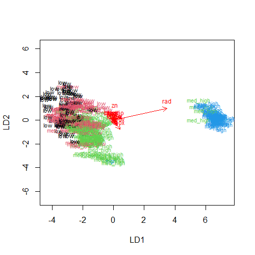

After that, I calculated the **probabilities of new observations** (test data) to belong to each one of the classes previously defined.The results are shown in the following crosstabulation table:

```r
test <- boston_scaled[-ind,]
      correct_classes <- test$crime
      test <- dplyr::select(test, -crime)
lda.pred <- predict(lda.fit, newdata = test)
table(correct = correct_classes, predicted = lda.pred$class)
```

```
##           predicted
## correct    low med_low med_high high
##   low       16       6        1    0
##   med_low    8      17        5    0
##   med_high   1       9        7    1
##   high       0       0        0   31
```

I also calculated the **Euclidean and Manhattan distance** between the variables on the scaled dataset. The following tables contain a summary of the pairwise distances of the observations.The mean Euclidean distance is smaller than the mean Manhattan distance.

```r
      boston_standarized <- scale(Boston)
      boston_standarized <- as.data.frame(boston_standarized)

dist_eu <- dist(boston_standarized)
summary(dist_eu)
```

```
##    Min. 1st Qu.  Median    Mean 3rd Qu.    Max.
##  0.1343  3.4625  4.8241  4.9111  6.1863 14.3970
```

```r
dist_mh <- dist(boston_standarized, method = "manhattan")
summary(dist_mh)
```

```
##    Min. 1st Qu.  Median    Mean 3rd Qu.    Max.
##  0.2662  8.4832 12.6090 13.5488 17.7568 48.8618
```

Next step was to apply the **k-means** algorithm on the dataset. The plot below is a visualization of the clusters obtained with this method.

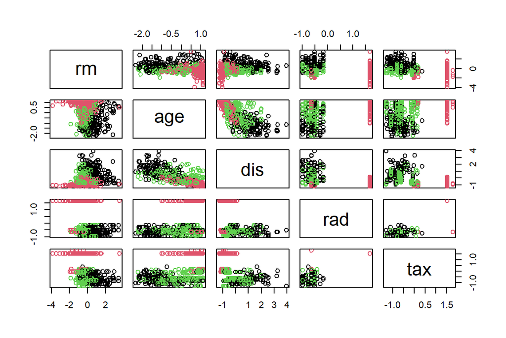

```r
km <-kmeans(boston_standarized, centers = 3)
pairs(boston_standarized[6:10], col = km$cluster)
```

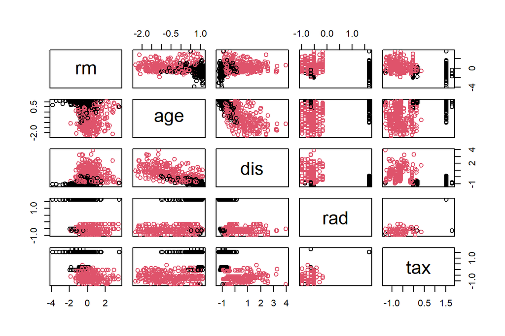

```r
km2 <-kmeans(boston_standarized, centers = 2)
pairs(boston_standarized[6:10], col = km2$cluster)
```

# Dimensionality reduction techniques

First, let´s load the packages used for the exercise.

```r
library(ggplot2)
library(GGally)
library(corrplot)
library(tidyverse)
library(factoextra)
library(FactoMineR)
```

In exercise 5 we are using a dataset which consists of records of variables used to calculate the Human Development Index in the 155 countries in the world, such as Life expectancy, years of schooling, etc.

```r
human <- read.table("http://s3.amazonaws.com/assets.datacamp.com/production/course_2218/datasets/human2.txt", sep  =",", header = T)
```

The dataset contains 155 observations and 8 variables. The mean life expectancy according to the observations is 71.65 years, being Japan the country with the highest life expectancy (83.50) and Swaziland the lowest (49 years).

```r
summary(human)
```

```
##     Edu2.FM          Labo.FM          Edu.Exp         Life.Exp
##  Min.   :0.1717   Min.   :0.1857   Min.   : 5.40   Min.   :49.00
##  1st Qu.:0.7264   1st Qu.:0.5984   1st Qu.:11.25   1st Qu.:66.30
##  Median :0.9375   Median :0.7535   Median :13.50   Median :74.20
##  Mean   :0.8529   Mean   :0.7074   Mean   :13.18   Mean   :71.65
##  3rd Qu.:0.9968   3rd Qu.:0.8535   3rd Qu.:15.20   3rd Qu.:77.25
##  Max.   :1.4967   Max.   :1.0380   Max.   :20.20   Max.   :83.50
##       GNI            Mat.Mor         Ado.Birth         Parli.F
##  Min.   :   581   Min.   :   1.0   Min.   :  0.60   Min.   : 0.00
##  1st Qu.:  4198   1st Qu.:  11.5   1st Qu.: 12.65   1st Qu.:12.40
##  Median : 12040   Median :  49.0   Median : 33.60   Median :19.30
##  Mean   : 17628   Mean   : 149.1   Mean   : 47.16   Mean   :20.91
##  3rd Qu.: 24512   3rd Qu.: 190.0   3rd Qu.: 71.95   3rd Qu.:27.95
##  Max.   :123124   Max.   :1100.0   Max.   :204.80   Max.   :57.50
```

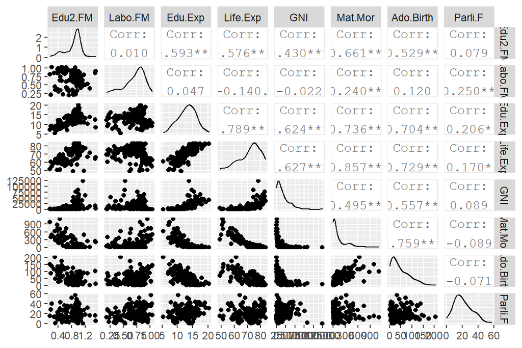

```r
ggpairs(human, lower = list(combo = wrap("facethist", bins = 20)))
```

Regarding the possible relationships between the variables and their **distributions**, none of the variables seem to strictly follow a normal distribution, except *Edu.Exp* (expected years of schooling). According to the *Pearson correlation coefficient* shown in the plot, there are highly significant correlations between many variables, i.e:

Life expectancy and Edu.Exp (+), Life expectancy and GNI (+), Life expectancy and Mat.Mor (-), Expected years of schooling and Ado.Birth (-).